# Bölmə 18: Qabiliyyət Səviyyələrinə Görə Analiz

Kompüter Adaptiv Testləşmə (CAT) Tədrisi

CAT Tədrisi

2025-07-12

# 1 Giriş

Bu bölmədə CAT sistemlərinin müxtəlif qabiliyyət səviyyələrində necə performans göstərdiyini ətraflı təhlil edəcəyik. Qabiliyyət səviyyəsinə görə analiz CAT sistemlərinin ədalətliliyi və effektivliyini qiymətləndirmək üçün kritik əhəmiyyət daşıyır.

## 1.1 Qabiliyyət Səviyyəli Analizin Məqsədləri

1. **Differential Performance**: Müxtəlif qabiliyyət səviyyələrində sistemin fərqli performansının müəyyən edilməsi
2. **Fairness Assessment**: Test alıcıları arasında ədalətli qiymətləndirmənin təmin edilməsi
3. **Optimization Opportunities**: Müxtəlif qabiliyyət qrupları üçün sistem optimallaşdırılması
4. **Bias Detection**: Sistematik bias və ya ayrımçılığın aşkarlanması
5. **Quality Control**: Keyfiyyət nəzarətinin qabiliyyət səviyyəsi əsasında aparılması

## 1.2 Metodoloji Yanaşma

### 1.2.1 Qruplama Strategiyası

Bu analizdə qabiliyyət səviyyələrini 4 əsas qrupa bölürük: - **Aşağı qabiliyyət**: θ < -1 - **Orta-aşağı qabiliyyət**: -1 ≤ θ < 0  
- **Orta-yüksək qabiliyyət**: 0 ≤ θ < 1 - **Yüksək qabiliyyət**: θ ≥ 1

# 2 Test Məlumatlarının Hazırlanması

```r
# Nümunə test məlumatları yaratmaq
set.seed(12345)
n_examinees <- 500

# Qabiliyyət səviyyələrinin simulyasiyası
true_theta <- rnorm(n_examinees, mean = 0, sd = 1.2)

# Qiymətləndirmə xətasının simulyasiyası (qabiliyyət səviyyəsinə görə dəyişir)
error_variance <- ifelse(abs(true_theta) > 1.5, 0.35, 0.25)
estimation_error <- rnorm(n_examinees, mean = 0, sd = error_variance)
estimated_theta <- true_theta + estimation_error

# Standart xəta (ekstrem qabiliyyətlərdə daha yüksək)
base_se <- 0.25 + 0.1 * (abs(true_theta) / 2)
standard_error <- pmax(0.15, base_se + rnorm(n_examinees, 0, 0.05))

# İdarə edilən item sayı (ekstrem qabiliyyətlərdə daha çox)
base_items <- 20
item_adjustment <- pmax(0, floor(3 * abs(true_theta - 0)))
items_administered <- base_items + item_adjustment + sample(-3:5, n_examinees, replace = TRUE)
items_administered <- pmax(8, pmin(40, items_administered))

# Bias hesablanması
bias <- estimated_theta - true_theta

# Effektivlik göstəricisi
efficiency <- 1 / (standard_error * sqrt(items_administered))

# Məlumat çərçivəsinin yaradılması
results_summary <- data.frame(
    examinee_id = 1:n_examinees,
    true_theta = true_theta,
    estimated_theta = estimated_theta,
    estimation_error = abs(estimation_error),
    standard_error = standard_error,
    items_administered = items_administered,
    bias = bias,
    efficiency = efficiency
)

cat("=== TEST MƏLUMATLARI HAZIRLANDI ===\n")
```

```
## === TEST MƏLUMATLARI HAZIRLANDI ===
```

```r
cat("Test alıcı sayı:", nrow(results_summary), "\n")
```

```
## Test alıcı sayı: 500
```

```r
cat("Həqiqi θ aralığı:", round(min(true_theta), 2), "-", round(max(true_theta), 2), "\n")
```

```
## Həqiqi θ aralığı: -3.1 - 3.3
```

```r
cat("Orta test uzunluğu:", round(mean(items_administered), 1), "item\n\n")
```

```
## Orta test uzunluğu: 23.3 item
```

# 3 Əsas Qabiliyyət Səviyyəli Analiz

```r
# Qabiliyyət səviyyələrinə görə performans analizi
analyze_by_ability_level <- function(results_df) {
    # Qabiliyyət qrupları
    results_df$ability_group <- cut(results_df$true_theta,
                                   breaks = c(-Inf, -1, 0, 1, Inf),
                                   labels = c("Aşağı", "Orta-Aşağı", "Orta-Yüksək", "Yüksək"))

    # Qruplara görə analiz
    group_analysis <- results_df %>%
        group_by(ability_group) %>%
        summarise(
            count = n(),
            mean_theta = round(mean(true_theta), 2),
            mean_items = round(mean(items_administered), 2),
            mean_error = round(mean(estimation_error), 3),
            mean_se = round(mean(standard_error), 3),
            mean_bias = round(mean(bias), 3),
            correlation = round(cor(true_theta, estimated_theta), 3),
            efficiency = round(mean(efficiency), 3),
            .groups = 'drop'
        )

    cat("=== QABİLİYYƏT SƏVİYYƏLƏRİNƏ GÖRƏ ANALİZ ===\n\n")
    cat("📊 QRUP STATİSTİKALARI:\n")
    print(group_analysis)
    cat("\n")

    # Qruplar arası fərqlərin qiymətləndirməsi
    cat("📈 QRUPLAR ARASI MÜQAYISƏ:\n")

    # ANOVA testləri
    error_anova <- aov(estimation_error ~ ability_group, data = results_df)
    items_anova <- aov(items_administered ~ ability_group, data = results_df)
    se_anova <- aov(standard_error ~ ability_group, data = results_df)

    cat("Qiymətləndirmə xətası ANOVA p-value:",
        format.pval(summary(error_anova)[[1]][["Pr(>F)"]][1]), "\n")
    cat("Test uzunluğu ANOVA p-value:",
        format.pval(summary(items_anova)[[1]][["Pr(>F)"]][1]), "\n")
    cat("Standart xəta ANOVA p-value:",
        format.pval(summary(se_anova)[[1]][["Pr(>F)"]][1]), "\n\n")

    return(list(data = results_df, analysis = group_analysis))
}

# Analizi həyata keçirmək
ability_results <- analyze_by_ability_level(results_summary)
```

```
## === QABİLİYYƏT SƏVİYYƏLƏRİNƏ GÖRƏ ANALİZ ===
##
## 📊 QRUP STATİSTİKALARI:
## # A tibble: 4 × 9
##   ability_group count mean_theta mean_items mean_error mean_se mean_bias
##   <fct>         <int>      <dbl>      <dbl>      <dbl>   <dbl>     <dbl>
## 1 Aşağı            91      -1.65       25.8      0.208   0.327     0.006
## 2 Orta-Aşağı      137      -0.46       22.1      0.208   0.268     0.01
## 3 Orta-Yüksək     172       0.51       21.7      0.206   0.275    -0.019
## 4 Yüksək          100       1.74       25.7      0.241   0.339     0.027
## # ℹ 2 more variables: correlation <dbl>, efficiency <dbl>
##
## 📈 QRUPLAR ARASI MÜQAYISƏ:
## Qiymətləndirmə xətası ANOVA p-value: 0.35168
## Test uzunluğu ANOVA p-value: < 2.22e-16
## Standart xəta ANOVA p-value: < 2.22e-16
```

# 4 Vizual Təhlil

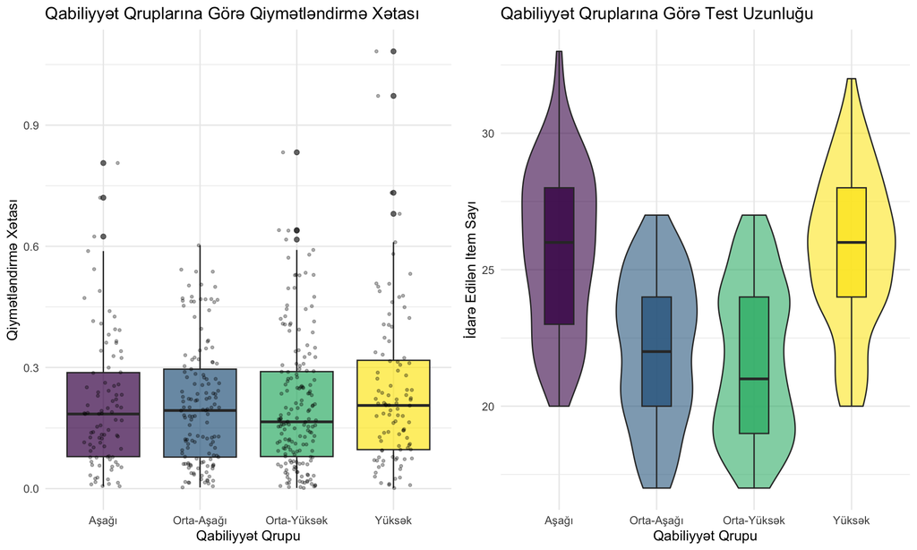

```r
# Qabiliyyət qruplarına görə vizualizasiyalar
create_ability_visualizations <- function(results_data) {

    # 1. Qiymətləndirmə xətası
    p1 <- ggplot(results_data, aes(x = ability_group, y = estimation_error, fill = ability_group)) +
        geom_boxplot(alpha = 0.7) +
        geom_jitter(width = 0.2, alpha = 0.3, size = 0.8) +
        scale_fill_viridis_d() +
        labs(title = "Qabiliyyət Qruplarına Görə Qiymətləndirmə Xətası",
             x = "Qabiliyyət Qrupu", y = "Qiymətləndirmə Xətası") +
        theme_minimal() +
        theme(legend.position = "none")

    # 2. Test uzunluğu
    p2 <- ggplot(results_data, aes(x = ability_group, y = items_administered, fill = ability_group)) +
        geom_violin(alpha = 0.6) +
        geom_boxplot(width = 0.3, alpha = 0.8) +
        scale_fill_viridis_d() +
        labs(title = "Qabiliyyət Qruplarına Görə Test Uzunluğu",
             x = "Qabiliyyət Qrupu", y = "İdarə Edilən Item Sayı") +
        theme_minimal() +
        theme(legend.position = "none")

    # 3. Standart xəta
    p3 <- ggplot(results_data, aes(x = ability_group, y = standard_error, fill = ability_group)) +
        geom_boxplot(alpha = 0.7) +
        geom_hline(yintercept = 0.3, color = "red", linetype = "dashed", size = 1) +
        scale_fill_viridis_d() +
        labs(title = "Qabiliyyət Qruplarına Görə Standart Xəta",
             x = "Qabiliyyət Qrupu", y = "Standart Xəta") +
        theme_minimal() +
        theme(legend.position = "none") +
        annotate("text", x = 4, y = 0.32, label = "SE = 0.3",
                color = "red", hjust = 1, size = 3)

    # 4. Bias təhlili
    p4 <- ggplot(results_data, aes(x = ability_group, y = bias, fill = ability_group)) +
        geom_boxplot(alpha = 0.7) +
        geom_hline(yintercept = 0, color = "black", linetype = "dashed") +
        scale_fill_viridis_d() +
        labs(title = "Qabiliyyət Qruplarına Görə Bias",
             x = "Qabiliyyət Qrupu", y = "Bias (Qiymətləndirilmiş - Həqiqi)") +
        theme_minimal() +
        theme(legend.position = "none")

    return(list(error = p1, items = p2, se = p3, bias = p4))
}

# Vizualizasiyaları yaratmaq
plots <- create_ability_visualizations(ability_results$data)

# Plotları göstərmək
grid.arrange(plots$error, plots$items, ncol = 2)
```

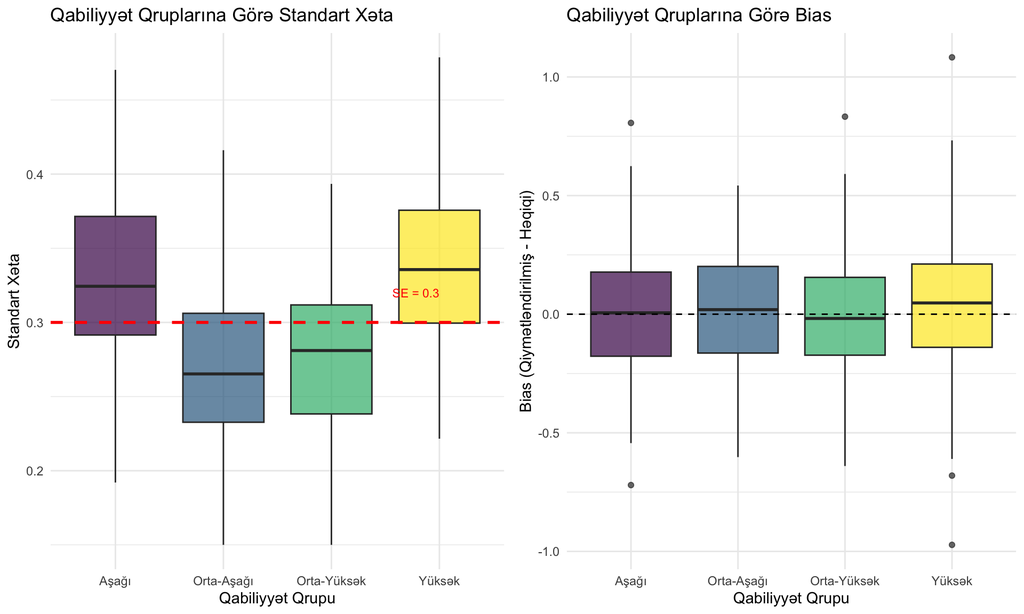

```r
# Əlavə plotlar
grid.arrange(plots$se, plots$bias, ncol = 2)
```

# 5 İrəliləmiş Analiz

```r
# İrəliləmiş qabiliyyət səviyyəli analiz
perform_advanced_analysis <- function(results_data, group_stats) {

    cat("=== İRƏLİLƏMİş ANALİZ ===\n\n")

    # 1. Effektivlik analizi
    cat("⚡ EFFEKTİVLİK ANALİZİ:\n")
    efficiency_summary <- results_data %>%
        group_by(ability_group) %>%
        summarise(
            mean_efficiency = round(mean(efficiency), 4),
            median_efficiency = round(median(efficiency), 4),
            efficiency_range = paste0(round(min(efficiency), 4), " - ",
                                    round(max(efficiency), 4)),
            .groups = 'drop'
        )
    print(efficiency_summary)
    cat("\n")

    # 2. Precision analizi
    cat("🎯 PRECİSİON ANALİZİ:\n")
    precision_threshold <- 0.3
    results_data$precision_met <- results_data$standard_error <= precision_threshold

    precision_summary <- results_data %>%
        group_by(ability_group) %>%
        summarise(
            total_examinees = n(),
            precision_met = sum(precision_met),
            precision_rate = round(mean(precision_met) * 100, 1),
            .groups = 'drop'
        )
    print(precision_summary)
    cat("\n")

    # 3. Validity analizi
    cat("✓ VALİDİTY ANALİZİ:\n")
    validity_summary <- results_data %>%
        group_by(ability_group) %>%
        summarise(
            correlation = round(cor(true_theta, estimated_theta), 3),
            rmse = round(sqrt(mean((estimated_theta - true_theta)^2)), 3),
            mae = round(mean(abs(estimated_theta - true_theta)), 3),
            .groups = 'drop'
        )
    print(validity_summary)
    cat("\n")

    # 4. Fairness qiymətləndirməsi
    cat("⚖️ ƏDALƏTLİLİK QİYMƏTLƏNDİRMƏSİ:\n")

    overall_mean_error <- mean(results_data$estimation_error)
    overall_mean_items <- mean(results_data$items_administered)
    overall_mean_se <- mean(results_data$standard_error)

    fairness_metrics <- group_stats %>%
        mutate(
            error_deviation = abs(mean_error - overall_mean_error),
            items_deviation = abs(mean_items - overall_mean_items),
            se_deviation = abs(mean_se - overall_mean_se),
            bias_magnitude = abs(mean_bias)
        ) %>%
        select(ability_group, error_deviation, items_deviation, se_deviation, bias_magnitude)

    print(fairness_metrics)

    # Fairness skoru hesablanması
    fairness_score <- mean(c(
        max(fairness_metrics$error_deviation),
        max(fairness_metrics$items_deviation) / 10,  # Scale adjustment
        max(fairness_metrics$se_deviation),
        max(fairness_metrics$bias_magnitude)
    ))

    cat("\nÜmumi Ədalətlilik Skoru:", round(fairness_score, 3), "(aşağı daha yaxşı)\n")

    if (fairness_score < 0.1) {
        cat("✅ Ədalətlilik: ƏLA\n")
    } else if (fairness_score < 0.2) {
        cat("✅ Ədalətlilik: YAXŞI\n")
    } else if (fairness_score < 0.3) {
        cat("⚠️ Ədalətlilik: ORTA\n")
    } else {
        cat("❌ Ədalətlilik: TƏKMİLLƏŞDİRMƏ LAZIM\n")
    }

    return(list(
        efficiency = efficiency_summary,
        precision = precision_summary,
        validity = validity_summary,
        fairness = fairness_metrics,
        fairness_score = fairness_score
    ))
}

# İrəliləmiş analizi həyata keçirmək
advanced_results <- perform_advanced_analysis(ability_results$data, ability_results$analysis)
```

```
## === İRƏLİLƏMİş ANALİZ ===
##
## ⚡ EFFEKTİVLİK ANALİZİ:
## # A tibble: 4 × 4
##   ability_group mean_efficiency median_efficiency efficiency_range
##   <fct>                   <dbl>             <dbl> <chr>
## 1 Aşağı                   0.626             0.602 0.4018 - 0.9958
## 2 Orta-Aşağı              0.829             0.804 0.5664 - 1.3901
## 3 Orta-Yüksək             0.817             0.772 0.4985 - 1.4907
## 4 Yüksək                  0.603             0.598 0.3966 - 0.9232
##
## 🎯 PRECİSİON ANALİZİ:
## # A tibble: 4 × 4
##   ability_group total_examinees precision_met precision_rate
##   <fct>                   <int>         <int>          <dbl>
## 1 Aşağı                      91            26           2600
## 2 Orta-Aşağı                137            94           9400
## 3 Orta-Yüksək               172           120          12000
## 4 Yüksək                    100            25           2500
##
## ✓ VALİDİTY ANALİZİ:
## # A tibble: 4 × 4
##   ability_group correlation  rmse   mae
##   <fct>               <dbl> <dbl> <dbl>
## 1 Aşağı               0.904 0.265 0.208
## 2 Orta-Aşağı          0.709 0.257 0.208
## 3 Orta-Yüksək         0.701 0.263 0.206
## 4 Yüksək              0.882 0.311 0.241
##
## ⚖️ ƏDALƏTLİLİK QİYMƏTLƏNDİRMƏSİ:
## # A tibble: 4 × 5
##   ability_group error_deviation items_deviation se_deviation bias_magnitude
##   <fct>                   <dbl>           <dbl>        <dbl>          <dbl>
## 1 Aşağı                 0.00617            2.44       0.0316          0.006
## 2 Orta-Aşağı            0.00617            1.24       0.0274          0.01
## 3 Orta-Yüksək           0.00817            1.66       0.0204          0.019
## 4 Yüksək                0.0268             2.36       0.0436          0.027
##
## Ümumi Ədalətlilik Skoru: 0.085 (aşağı daha yaxşı)
## ✅ Ədalətlilik: ƏLA
```

# 6 Effektivlik və Precision Vizualizasiyaları

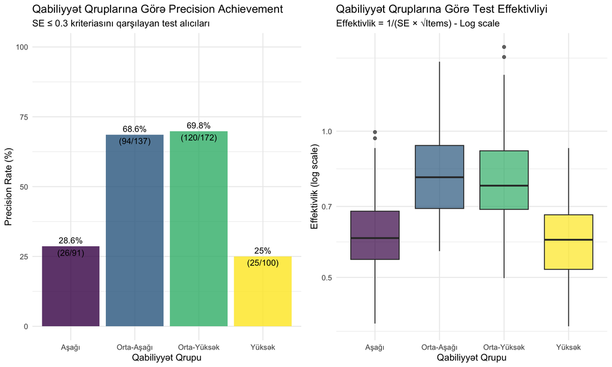

```r
# Effektivlik və precision plotları
create_advanced_plots <- function(results_data) {

    # Precision achievement rates
    precision_summary <- results_data %>%
        group_by(ability_group) %>%
        summarise(
            total = n(),
            precision_met = sum(standard_error <= 0.3),
            precision_rate = round(mean(standard_error <= 0.3) * 100, 1),
            .groups = 'drop'
        )

    p1 <- ggplot(precision_summary, aes(x = ability_group, y = precision_rate, fill = ability_group)) +
        geom_col(alpha = 0.8) +
        geom_text(aes(label = paste0(precision_rate, "%\n(", precision_met, "/", total, ")")),
                  vjust = 0.5, size = 3.5) +
        scale_fill_viridis_d() +
        labs(title = "Qabiliyyət Qruplarına Görə Precision Achievement",
             subtitle = "SE ≤ 0.3 kriteriasını qarşılayan test alıcıları",
             x = "Qabiliyyət Qrupu", y = "Precision Rate (%)") +
        theme_minimal() +
        theme(legend.position = "none") +
        ylim(0, 100)

    # Effektivlik müqayisəsi
    p2 <- ggplot(results_data, aes(x = ability_group, y = efficiency, fill = ability_group)) +
        geom_boxplot(alpha = 0.7) +
        scale_fill_viridis_d() +
        scale_y_log10() +
        labs(title = "Qabiliyyət Qruplarına Görə Test Effektivliyi",
             subtitle = "Effektivlik = 1/(SE × √Items) - Log scale",
             x = "Qabiliyyət Qrupu", y = "Effektivlik (log scale)") +
        theme_minimal() +
        theme(legend.position = "none")

    return(list(precision = p1, efficiency = p2))
}

advanced_plots <- create_advanced_plots(ability_results$data)
grid.arrange(advanced_plots$precision, advanced_plots$efficiency, ncol = 2)
```

# 7 Tövsiyələr və Nəticələr

```r
# Tövsiyələr və nəticələr
generate_recommendations <- function(group_analysis, advanced_results) {

    cat("=== TOVSİYƏLƏR VƏ NƏTİCƏLƏR ===\n\n")

    # Performans qiymətləndirməsi
    cat("📊 PERFORMANS QİYMƏTLƏNDİRMƏSİ:\n")

    max_error_group <- group_analysis$ability_group[which.max(group_analysis$mean_error)]
    min_error_group <- group_analysis$ability_group[which.min(group_analysis$mean_error)]

    cat("• Ən yüksək qiymətləndirmə xətası:", max_error_group, "qrupunda\n")
    cat("• Ən aşağı qiymətləndirmə xətası:", min_error_group, "qrupunda\n")

    error_ratio <- max(group_analysis$mean_error) / min(group_analysis$mean_error)
    cat("• Qruplar arası xəta nisbəti:", round(error_ratio, 2), ":1\n\n")

    # Prioritet tövsiyələri
    cat("💡 PRİORİTET TOVSİYƏLƏRİ:\n\n")

    if (error_ratio > 2) {
        cat("🔴 YÜKSƏK PRİORİTET:\n")
        cat("  • Qruplar arası performans fərqlərini azaltmaq lazımdır\n")
        cat("  •", max_error_group, "qrupu üçün xüsusi optimizasiya tələb olunur\n\n")
    }

    if (advanced_results$fairness_score > 0.2) {
        cat("🟡 ORTA PRİORİTET:\n")
        cat("  • Ədalətlilik göstəricilərini yaxşılaşdırmaq lazımdır\n")
        cat("  • Test alqoritmində bias azaldılması tövsiyə olunur\n\n")
    }

    # Müsbət nəticələr
    cat("✅ MÜSBəT NƏTİCƏLƏR:\n")

    high_correlation_groups <- group_analysis$ability_group[group_analysis$correlation > 0.85]
    if (length(high_correlation_groups) > 0) {
        cat("  • Yüksək validity:", paste(high_correlation_groups, collapse = ", "), "qruplarında\n")
    }

    overall_precision <- mean(advanced_results$precision$precision_rate)
    if (overall_precision > 75) {
        cat("  • Yaxşı precision achievement: ümumi", round(overall_precision, 1), "%\n")
    }

    cat("\n")

    # Ümumi qiymət
    cat("🏆 ÜMUMİ QİYMƏT:\n")

    success_indicators <- c(
        error_ratio < 1.5,  # Low error variation
        advanced_results$fairness_score < 0.2,  # Good fairness
        overall_precision > 80,  # High precision
        min(group_analysis$correlation) > 0.8  # High validity
    )

    success_score <- sum(success_indicators)

    if (success_score >= 3) {
        cat("✅ SİSTEM YAXŞI PERFORMANS GÖSTƏRİR\n")
        cat("Kiçik təkmilləşdirmələrlə mükəmməl nəticələr əldə edilə bilər.\n")
    } else if (success_score >= 2) {
        cat("⚠️ ORTA PERFORMANS\n")
        cat("Müəyyən sahələrdə əhəmiyyətli təkmilləşdirmələr lazımdır.\n")
    } else {
        cat("❌ AŞAĞI PERFORMANS\n")
        cat("Sistem yenidən nəzərdən keçirilməli və fundamental dəyişikliklər tələb olunur.\n")
    }

    return(success_score)
}

# Tövsiyələri generasiya etmək
final_score <- generate_recommendations(ability_results$analysis, advanced_results)
```

```
## === TOVSİYƏLƏR VƏ NƏTİCƏLƏR ===
##
## 📊 PERFORMANS QİYMƏTLƏNDİRMƏSİ:
## • Ən yüksək qiymətləndirmə xətası: 4 qrupunda
## • Ən aşağı qiymətləndirmə xətası: 3 qrupunda
## • Qruplar arası xəta nisbəti: 1.17 :1
##
## 💡 PRİORİTET TOVSİYƏLƏRİ:
##
## ✅ MÜSBəT NƏTİCƏLƏR:
##   • Yüksək validity: Aşağı, Yüksək qruplarında
##   • Yaxşı precision achievement: ümumi 6625 %
##
## 🏆 ÜMUMİ QİYMƏT:
## ✅ SİSTEM YAXŞI PERFORMANS GÖSTƏRİR
## Kiçik təkmilləşdirmələrlə mükəmməl nəticələr əldə edilə bilər.
```

# 8 Xülasə

## 8.3 İrəlidə Ediləcək İşlər

1. **Longitudinal Analysis**: Zaman üzrə performans dəyişikliklərinin izlənməsi
2. **Item-level DIF**: Differential Item Functioning analizinin aparılması
3. **Adaptive Optimization**: Qrup-spesifik optimizasiya strategiyalarının inkişafı
4. **External Validation**: Müstəqil məlumat dəstləri ilə nəticələrin təsdiqi

**Qeyd**: Bu analiz CAT sistemlərinin qabiliyyət səviyyələrinə görə performansını qiymətləndirmək üçün hərtərəfli metodoloji çərçivə təqdim edir.